# 6: Morphospace Plots

Author

Ryan N. Felice

```r
#remotes::install_github("millacarmona/morphospace")
library(morphospace)
library(geomorph)
library(phytools)
library(Morpho)
library(tidyverse)
library(Rvcg)
library(rgl)
library(scatterplot3d)
```

## What is a morphospace and what is it good for?

Lets practice making nice morphospace plots using some landmark data. Morphospace plots are just a fancy way of saying “ordination plot.” With GMM data, we are typically talking about plotting principal component analyses (PCA).

Here is an example:

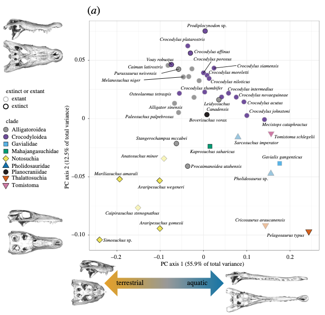

Felice, R. N., D. Pol, and A. Goswami. 2021. Complex macroevolutionary dynamics underly the evolution of the crocodyliform skull. Proceedings of the Royal Society B: Biological Sciences 288:20210919.

There is a lot of data packed into this plot! The most important this is seeing which data points (in this case, species, but it could be individuals) are similar and different from one another. The colors and shapes tell us about the phylogenetic affinities and whether the species is extinct. The images on the x and y axes show us which aspects of shape are most variable and how shape variation partitions specimens.

Lets try to recreate something like this!

```r
#import data:
raw_data<-read.csv('./Data/crocs.csv',row.names = 1)
shape_data <- arrayspecs(raw_data, p=ncol(raw_data)/3, k=3)
#remove one specimen that has no ecology data:
bad_specimen <- which(dimnames(shape_data)[[3]]== "Crocodylus_biporcatus")
shape_data <- shape_data[,,-bad_specimen]
#phylogeny:
phylo1 <- read.nexus('./Data/CrocTree2.nex')
#ecological data
eco_dat <- read_csv('./Data/croc_ecology_data.csv')
#make sure tips and data are in same order
shape_data <- shape_data[,,eco_dat$Tip_label]
```

Now do a Procrustes superimposition and carry out a principal components analysis of the aligned landmark coordinates.

```r
gpa <- gpagen(shape_data)
```

```
Performing GPA


Making projections... Finished!
```

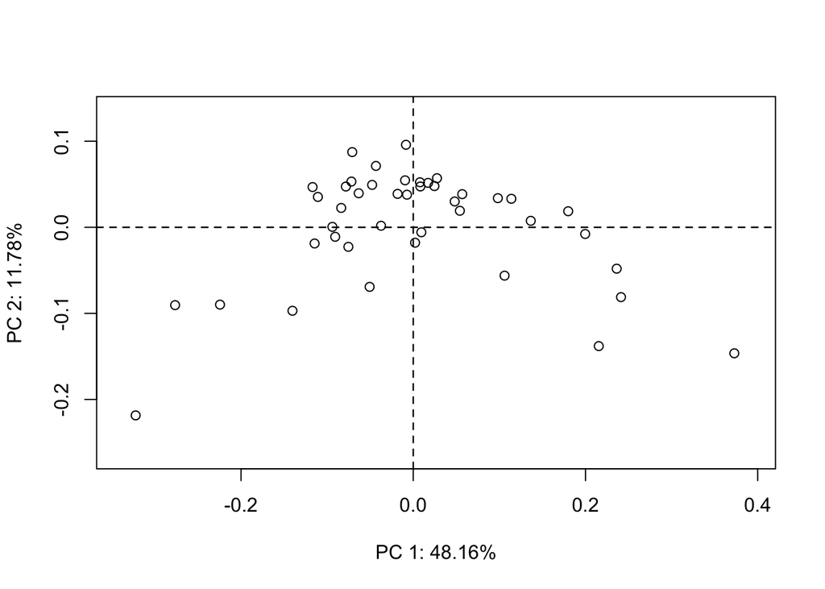

```r
PCA <- gm.prcomp(gpa$coords)
#look at the morphospace
plot(PCA)
```

Pretty boring, right? and there really isn’t much we can learn from this on its own.

Some of the things we might want to explore/visualize in a morphospace:

- how is shape variation distributed?
- do species with similar ecology cluster together?
- do species with similar body size have similar skull shapes?

The `morphospace` package makes it very easy to do these sorts of data explorations

```
Preparing for snapshot: rotate mean shape to the desired orientation
 (don't close or minimize the rgl device).Press <Enter> in the console to continue:

This can take a few seconds...
DONE.
```

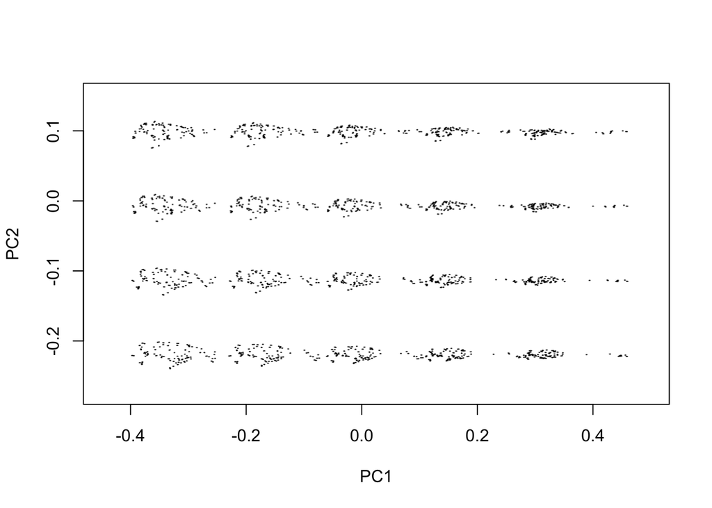

```r
#define some good color-blind friendly colors:
#see https://davidmathlogic.com/colorblind/#%23D81B60-%231E88E5-%23FFC107-%23004D40
cbb_colors<-c("#D81B60","#1E88E5","#FFC107","#004D40","black")
habitats<-as.factor(eco_dat$Habitat)
names(habitats)<-eco_dat$Tip_label
fossils<-as.factor(eco_dat$extinct)
names(fossils)<-eco_dat$Tip_label
habitat_colors<-cbb_colors[habitats]
mspace(gpa$coords)
```

```r
msp<-mspace(gpa$coords, plot=FALSE) %>%
  # scatter points
  proj_shapes(shapes = gpa$coords, col = habitat_colors) %>%
  # convex hulls enclosing groups
  proj_groups( groups = habitats, col=cbb_colors[1:3], alpha = 0.5) %>%
    plot_mspace(legend = TRUE, cex.legend = .7)
```

[output not shown]

I Still think those clusters of landmarks are hard to interpret- lets use warps of a mesh of a specimen

```r
#load in a mesh
m1<-vcgImport("./Data/Alligator_mississippiensis.ply")
shade3d(m1, col="#E4D1C0", specular="black")
#make a "hypothetical shape",
#the mean of all specimens,
#by warping the skull of the alligator to the landmark configuration of the mean specimen
mean_skull <- warpRefMesh(mesh=m1,
                          mesh.coord = shape_data[,,"Alligator_mississippiensis"],
                          gpa$consensus)
```

and now plot with 3D models representing shape change:

```
Preparing for snapshot: rotate mean shape to the desired orientation
 (don't close or minimize the rgl device).Press <Enter> in the console to continue:

This can take a few seconds...
DONE.
```

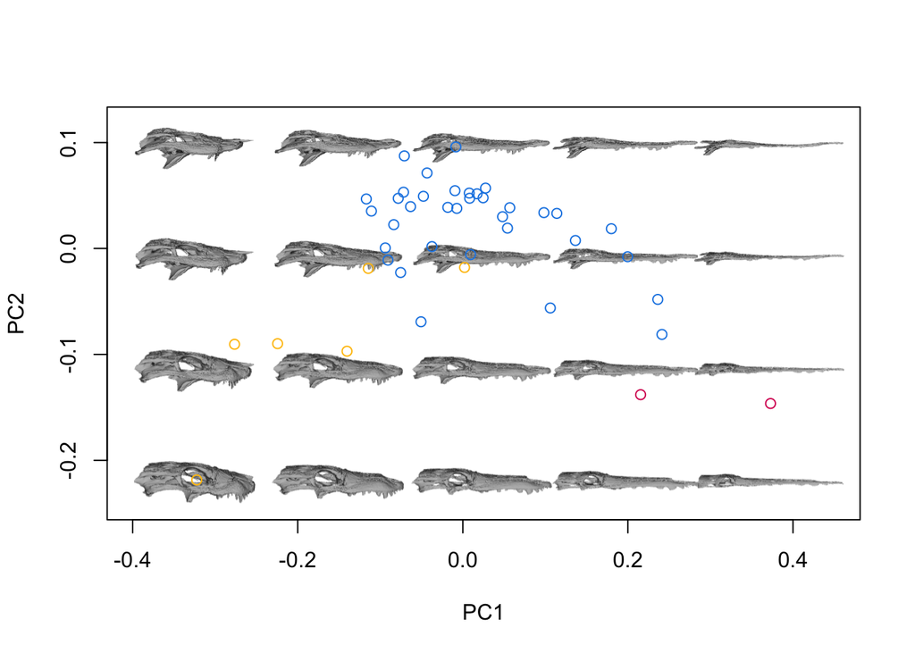

```r
mspace(gpa$coords, template= mean_skull,bg.model = "gray",
                  cex.ldm = 0, adj_frame = c(0.9, 0.85)) %>%
  # scatter points
  proj_shapes(shapes = gpa$coords, col = habitat_colors)
```

## Phylomorphospace

Another useful way of using morphospace is to project the phylogenetic tree into the ordination so that we can make hypotheses about how evolutionary relationships relate to phenotypic similarities or differences. For example, this will help us see if there could be convergent evolution if we see two species with very similar shapes (positions in morphospace) that have ancestors in completely different parts of morphospace.

```
Preparing for snapshot: rotate mean shape to the desired orientation
 (don't close or minimize the rgl device).Press <Enter> in the console to continue:

This can take a few seconds...
DONE.
```

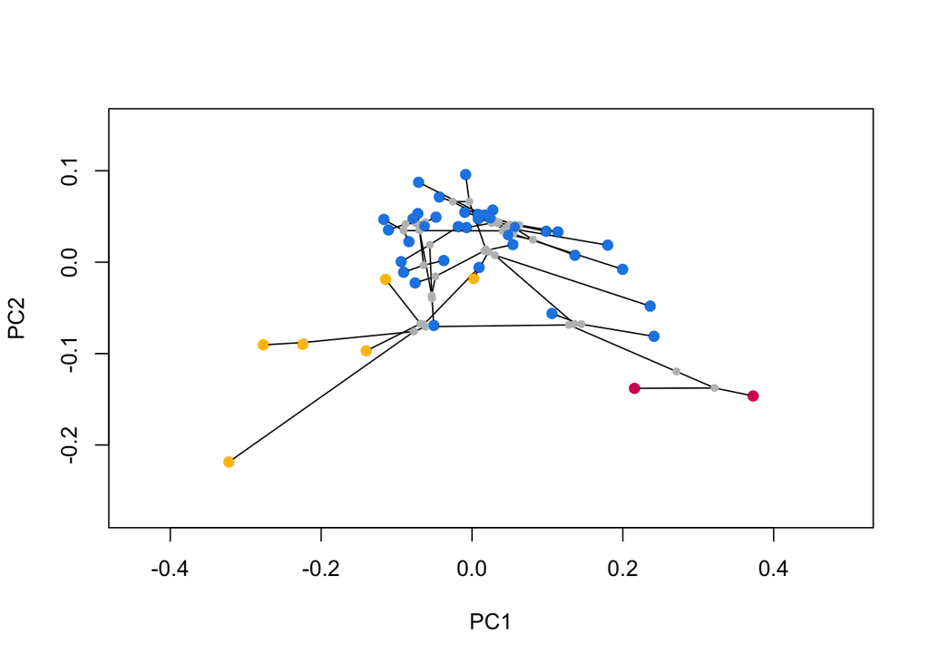

```r
eco_dat_phylo<-eco_dat[match(phylo1$tip.label, eco_dat$Tip_label),]
habitats_phylo<-as.factor(eco_dat_phylo$Habitat)
names(habitats_phylo)<-eco_dat_phylo$Tip_label
tip_colors<-cbb_colors[habitats_phylo]

msp<-mspace(gpa$coords, models=FALSE) %>%
  # scatter points
  proj_shapes(shapes = gpa$coords, col = habitat_colors) %>%
  # phylogenetic relationships
  proj_phylogeny(shapes = gpa$coords, tree = phylo1, col.tips=tip_colors)
```

- Do we notice any convergence?
- See if you can add tip labels to the plot so you can see which taxa are (potentially) converging!

## Other Ways of Plotting Morphospace

Let’s try a different type of morphospace plot that is particularly relevant to us as paleontologists.

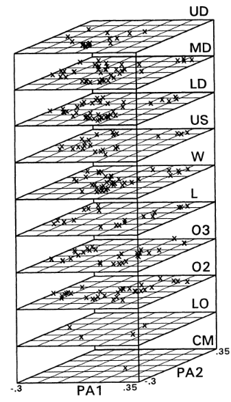

From: Foote, M. 1994. Morphological disparity in Ordovician-Devonian crinoids and the early saturation of morphological space. *Paleobiology* 20:320–344.

As paleontologists, we might be interested in how morphological variation expands and contracts through time.

First, lets prep by:

1. calculating the % variance explained by each PC axis so we can add that to the axis labels
2. We need a way to tell R how far apart to place the grids that represent time periods. We have a vector, `eco_dat$time`, that lists the time bin in which each species lived. We need to change these to equally spaced numerical bins that will become the z-axis values for the plot.

```r
PCA_summary<-invisible(summary(PCA))
```

```
Ordination type: Principal Component Analysis
Centering by OLS mean
Orthogonal projection of OLS residuals
Number of observations: 43
Number of vectors 42

Importance of Components:
                            Comp1       Comp2       Comp3       Comp4
Eigenvalues            0.01863466 0.004560141 0.002363625 0.001798776
Proportion of Variance 0.48157394 0.117847348 0.061082951 0.046485627
Cumulative Proportion  0.48157394 0.599421285 0.660504236 0.706989863
                             Comp5      Comp6        Comp7        Comp8
Eigenvalues            0.001503002 0.00105661 0.0008890967 0.0007642375
Proportion of Variance 0.038841957 0.02730589 0.0229768510 0.0197501259
Cumulative Proportion  0.745831819 0.77313771 0.7961145639 0.8158646898
                             Comp9       Comp10       Comp11       Comp12
Eigenvalues            0.000690656 0.0006627848 0.0005826994 0.0005479097
Proportion of Variance 0.017848564 0.0171282911 0.0150586522 0.0141595852
Cumulative Proportion  0.833713254 0.8508415449 0.8659001971 0.8800597823
                             Comp13       Comp14       Comp15       Comp16
Eigenvalues            0.0004476335 0.0004215015 0.0003661049 0.0003399192
Proportion of Variance 0.0115681536 0.0108928264 0.0094612179 0.0087845023
Cumulative Proportion  0.8916279358 0.9025207622 0.9119819801 0.9207664824
                             Comp17       Comp18      Comp19       Comp20
Eigenvalues            0.0002878028 0.0002708908 0.000245226 0.0002297029
Proportion of Variance 0.0074376629 0.0070006089 0.006337354 0.0059361919
Cumulative Proportion  0.9282041453 0.9352047542 0.941542108 0.9474783002
                            Comp21       Comp22       Comp23       Comp24
Eigenvalues            0.000220447 0.0001809923 0.0001791846 0.0001552528
Proportion of Variance 0.005696993 0.0046773698 0.0046306526 0.0040121846
Cumulative Proportion  0.953175293 0.9578526632 0.9624833158 0.9664955004
                             Comp25       Comp26       Comp27       Comp28
Eigenvalues            0.0001454897 0.0001343652 0.0001206231 0.0001176935
Proportion of Variance 0.0037598775 0.0034723885 0.0031172529 0.0030415433
Cumulative Proportion  0.9702553779 0.9737277664 0.9768450193 0.9798865626
                             Comp29       Comp30       Comp31       Comp32
Eigenvalues            0.0001023449 8.575332e-05 8.469609e-05 7.284477e-05
Proportion of Variance 0.0026448907 2.216116e-03 2.188794e-03 1.882521e-03
Cumulative Proportion  0.9825314533 9.847476e-01 9.869364e-01 9.888189e-01
                             Comp33       Comp34       Comp35       Comp36
Eigenvalues            0.0000659296 6.345064e-05 5.404416e-05 0.0000490079
Proportion of Variance 0.0017038131 1.639750e-03 1.396659e-03 0.0012665069
Cumulative Proportion  0.9905226975 9.921624e-01 9.935591e-01 0.9948256126
                             Comp37       Comp38       Comp39       Comp40
Eigenvalues            4.711339e-05 4.190097e-05 3.529723e-05 2.894756e-05
Proportion of Variance 1.217547e-03 1.082843e-03 9.121833e-04 7.480893e-04
Cumulative Proportion  9.960432e-01 9.971260e-01 9.980382e-01 9.987863e-01
                             Comp41       Comp42
Eigenvalues            2.814711e-05 1.881835e-05
Proportion of Variance 7.274033e-04 4.863210e-04
Cumulative Proportion  9.995137e-01 1.000000e+00
```

```r
time_period<-as.factor(eco_dat$time)
levels(time_period)<-c(40,20,0,60)
time_period2<-as.numeric(as.character(time_period))
```

Now we can build the plot

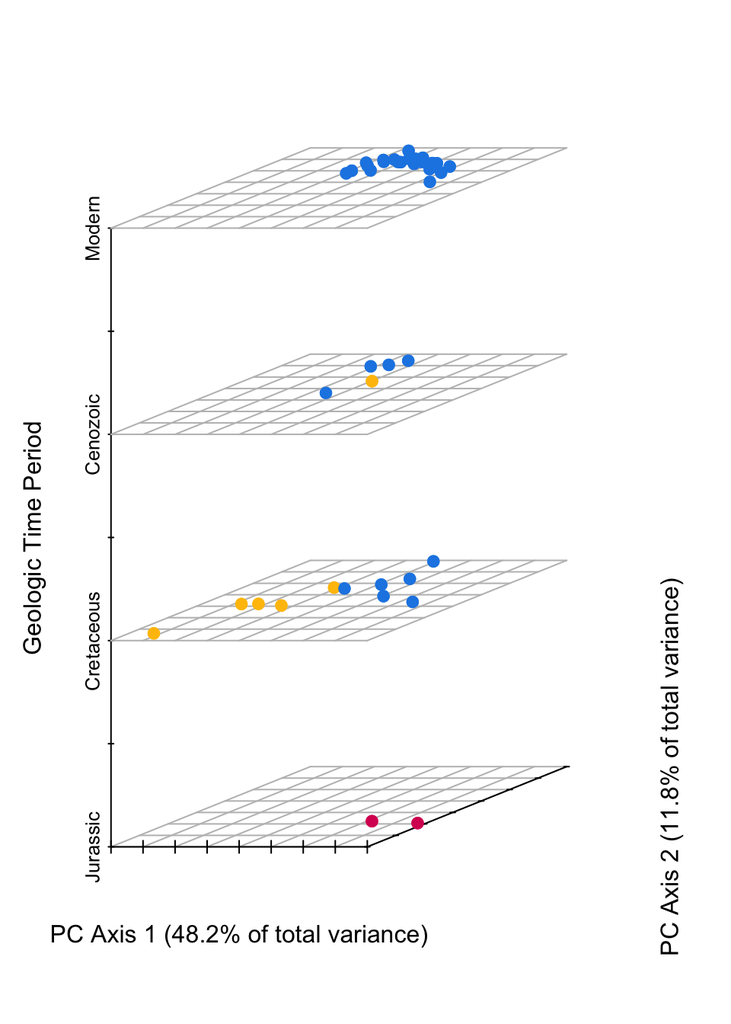

```r
#stacked morphospace

plot3d1<-scatterplot3d(x = PCA$x[,1], #PC axis 1 scores
                       y = PCA$x[,2], #PC axis 2 scores
                       z = time_period2, #time bins
                       pch =19, #shape of the points
                       angle = 10,
                       color=habitat_colors, #color the points
                       z.ticklabs=c("Jurassic",
                                    "",
                                    "Cretaceous",
                                    "",
                                    "Cenozoic",
                                    "",
                                    "Modern"),
                       xlab=paste0("PC Axis 1 (",
                                   signif(PCA_summary$PC.summary[2,1],3)*100,
                                   "% of total variance)"),
                       ylab=paste0("PC Axis 2 (",
                                   signif(PCA_summary$PC.summary[2,2],3)*100,
                                   "% of total variance)"),
                       label.tick.marks = TRUE,
                       zlab="Geologic Time Period",
                       #additional graphics options for a clean plot
                       box=F,x.ticklabs=NA,y.ticklabs=NA)
plot3d1$plane3d(20,0,0,lty="solid",col="grey")
plot3d1$plane3d(40,0,0,lty="solid",col="grey")
plot3d1$plane3d(60,0,0,lty="solid",col="grey")
plot3d1$points3d(x = PCA$x[,1],
                       y = PCA$x[,2],
                       z = time_period2,
                       pch =19,
                       col=habitat_colors)
```

looks pretty good!

- Try experimenting with the “angle” argument in `scatterplot3d` to see how you can change the appearance of the plot.
- What does this tell us about morphospace occupation through time and changes in morphological disparity through time?
- What are some issues with this dataset that this plot reveals?